# gemR :: An integration of GEM with R

[figure not shown]

*Integration of GEM with R*

## Contents

- Software requirements
- Installation
- To run via the shiny app
- To run via R script
- Creating a demand file
- Input files
- To do
- App screenshots

## Software requirements

- [R](https://cran.r-project.org/bin/windows/base/) - current project version: 3.6.0
- [RStudio](https://www.rstudio.com/products/rstudio/download/)
- [GAMS](https://www.gams.com/download/) - current project version: 25.3
- [git](https://git-scm.com/downloads) - this is more of a nice-to-have as you can still download the project as a zip file from GitHub.

## Installation

1. Open a command prompt (or git bash) and navigate to the path you would like to clone the project repository to (e.g. `cd C:\apps\`).
2. Use **git** to clone the repository by typing the following: `git clone https://github.com/ElectricityAuthority/gemR.git`. This will create a copy of the `gemR` project in the location you navigated to in step 1.
3. Navigate to the `gemR` folder and open the project in **RStudio** (double-click on `gemR.Rproj`).
4. On loading the project for the first time, there is a check to see if the `packrat` package is installed (`packrat` is being used for package management and reproducibility). If it does not exist, **RStudio** will attempt to install it. (**NOTE**: if you have cloned the project to a mapped network drive you may see the error: *cannot set reparse point ‘…gemR/packrat/lib-R/x86_64-w64-mingw32/3.5.1/base’, reason ’Access is denied*. It is a known issue, just ignore it.)
5. Restore all packages required by the project using a call to `packrat::restore()`. **This will take a while but will only need to be done once - go grab a coffee!**.
6. Restart your **RStudio** session (`Session` > `Restart R`) - **an important step!**

## To run via the shiny app

1. Use the `Files` tab in RStudio to navigate to `Programs/R/gemR_shiny/`.
2. Open `ui.R` and click the `Run App` button at the top right of the script.
3. In the `Run GEM` tab, choose a run name, start and end dates and a demand file and click `Run`.
4. After the run has finished solving, explore the output in the `Results` tab.

## To run via R script

1. Use the `Files` tab in RStudio to navigate to `Programs/R/runGEM/`.
2. Open `runGEM.R`.
3. Update the parameter objects (run name, dates, etc.) at the top of the script.
4. Step through and run each subsequent section in sequence.
5. Plots are output to `Output/<run name>/Reports/plots/`.

## Creating a demand file

### Requirements (input files)

- Annual demand forecast for reference year (as a CSV). With the following columns:
  - `dttm` (datetime)
  - `tp` (trading period)
  - `poc` (point of connection)
  - `y` (year)
  - `mn` (month)
  - `d` (day)
  - `MWh` (demand in MWh)

**Note: an example is currently not provided on GitHub as the file is 170MB.**

- Annual electricity demand by POC and year (as a CSV). There is a forecast file currently available in this repository (`Data/Demand/Forecast/annual_energy_forecasts_by_GXP_2012_2050.csv`). The file is currently set up in wide format with the first column being `year` and the remaining columns the POCs. **Note: this file is out-of-date. There are only 180 POCs in this file.**

### Process

1. Navigate to `Programs/R/generateGEMDemand` and open `generateGEMDemand.R`.
2. Enter the paramaters at the top of the script for `year`, `forecast file`, `scenario suffix`, etc.
3. Run through the code step by step:
1. Read in the demand CSV.
2. Optionally, create time series plots demand for all POCs.
3. Generate load duration curves by POC (currently hard-coded 9 load blocks).
4. Sum load by POC, month and load block.
5. Optionally, plot all LDCs by POC.
6. Compute block weights (the proportion of demand) by POC, month and load block.
7. Compute load share (share of annual load) by POC and month.
8. Apportion annual load forecast to POCs based on block weights and load share.
9. Map POCs to regions using concordance (`Data/Geography/mapPOCsToRegions.csv`) - **Note: this concordance is not complete/up-to-date for all POCs at the moment.**
10. Output to CSV - the file is output to `Data/Demand/Archive_<datetime_suffix>`. This file can then be used as an input to `gemR`.

## Input files

**Sets**, **subsets** and **parameter** input CSVs can be found in the GEMdataInput folder.

**Setup variables** (`$setglobals` and scalar variables) can be found in the Setup folder.

For more information see the following [documentation](https://electricityauthority.github.io/gemR/Documentation/datasetsDocumentation.html).

## TODO

- ~fix code that generates the loss-related parameters (slope, intercept, etc.)~
- revisit GEMsolve code
- revisit model constraints
- integrate gemR with the DOASA hydro-scheduling model
- add validation and unit tests (use the *expect_* functions from the *testthat* package)
- set up logger (using the `log4r` package)
- update demand forecast data
- test using 18 region version
- move CSS from bottom of `ui.R` into css file.

## App screenshots

[figure not shown]

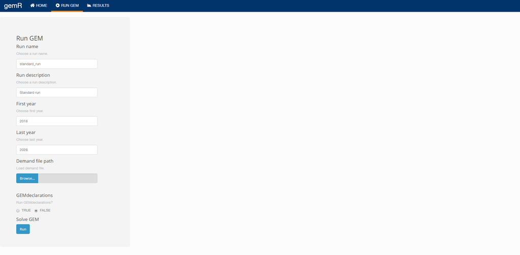

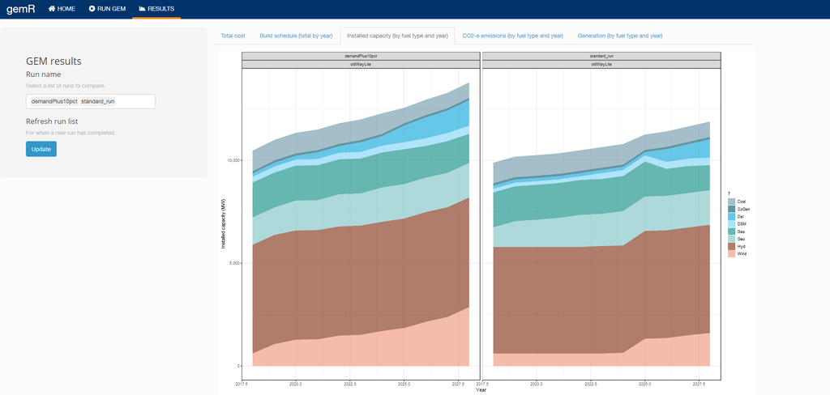